# Bootstrapping ziCPUE data

Lucas A. Nell

March 31, 2016

# 1 Initial setup

The following packages are required:

```r
library('dplyr')
library('readxl')
library('ggplot2')
library('boot')
library('broom')
library('RColorBrewer')
```

Read, clean, and add necessary columns to the table in `brett_example.xlsx`.

```r
CPUEdf <- read_excel("./from_Bill/brett_example.xlsx",1) %>%
    rename(Area = `Effort m^2`, Count = SumOfSPEC) %>%
    filter(Year %in% 1993:2013, !is.na(Year), Month == 10, !is.na(Month)) %>%
    select(Year, Month, Station, Count, Area) %>%
    mutate(CPUE = (Count/Area)*100) %>%
    arrange(Year)
```

# 2 Bootstrap resampling

For seamless bootstrapping with `dplyr`, the package `broom` provides the function `boostrap`.

I’ve grouped by `Year` to sample the same number of samples per year for each bootstrap resample as there were in the original sample.

If we represent each year’s sampling as…
$$n_1, n_2, n_3, \hspace{0.25em} ... \hspace{0.25em}, n_k$$

where

$$n_{total} = \sum_{i=1}^{k}{n_i}$$

Then what we’ll do below will maintain each of $n_1, \hspace{0.25em} ... \hspace{0.25em}, n_k$ (rather than just $n_{total}$) through all resamples.

```r
set.seed(9721)
CPUEboot <- CPUEdf %>%
    group_by(Year) %>%
    bootstrap(100, by_group = TRUE) %>%
    do(summarize(group_by(., Year), CPUE = mean(CPUE))) %>%
    ungroup %>%
    select(-replicate)

# Summary table
CPUEbootSumm <- CPUEboot %>%
    group_by(Year) %>%
    summarize(low = quantile(CPUE, probs = 0.025),
              mid = quantile(CPUE, probs = 0.5),
              high = quantile(CPUE, probs = 0.975))

CPUEbootSumm
```

```
# A tibble: 19 × 4
    Year         low         mid        high
   <dbl>       <dbl>       <dbl>       <dbl>
1   1993  5.11735428  9.75059899 17.34135390
2   1994  4.89192582 13.57410985 24.30088774
3   1995  5.47097630 17.02111263 29.82982826
4   1996  2.13538822 22.99904414 69.00689351
5   1997  3.39717961  6.90229182 12.11984363
6   1999  0.96982734  3.75378210  7.77268193
7   2000  0.14299671  0.37713653  0.70006896
8   2001  0.43512610  0.87801583  1.39304571
9   2002  0.02082519  0.07023048  0.14170401
10  2003  0.00000000  0.02068638  0.06242225
11  2004  0.19808913  0.70010874  1.48953558
12  2005 15.88711580 29.23924205 52.55254592
13  2006  0.36155904  0.54269896  0.85642028
14  2007  2.80429576  5.43329609  9.16050992
15  2008  5.46774259  8.40804876 12.95734297
16  2009  6.33726384 10.17844668 15.46315980
17  2010  0.37991837  0.85713207  1.49397186
18  2012  0.00000000  0.00000000  0.00000000
19  2013  0.00000000  0.02879065  0.05995872
```

# 3 Plotting

These are just some aesthetic pieces that I often employ. They’re included here in case others are interested.

```r
# Minimal ggplot2 theme
plotTheme <- function(base_size = 10, base_family = 'Helvetica') {
    theme_minimal(base_size = base_size, base_family = base_family) %+replace%
        theme(
            strip.text = element_text(face = 'bold'),
            panel.grid.minor = element_blank(),
            panel.grid.major.x = element_blank(),
            panel.grid.major.y = element_line(color = 'gray50', size = 0.125,
                                              linetype = 3),
            panel.border = element_rect(fill = NA, color = "gray50"),
            axis.ticks = element_line(color = "gray50"),
            axis.ticks.length = unit(2, 'points'),
            legend.position = 'none'
        )
}

# Color palette for unique values in an input vector
myPalette <- function(inputVector){
    outPalette <- inputVector %>%
        unique %>%
        length %>%
        colorRampPalette(brewer.pal(8,  'Dark2'))(.)
    return(outPalette)
}
```

### 3.0.1 Base plot

All following plots are based off this base one. Having no `geom`s, it just stores the data and some aesthetics that we’ll pass on to plots later.

```r
bootPlot <- CPUEdf %>%
    ggplot(aes(x = factor(Year), y = CPUE, color = factor(Year))) +
    plotTheme() +
    scale_x_discrete('Year', breaks = seq(min(CPUEdf$Year), max(CPUEdf$Year))) +
    scale_color_manual(values = myPalette(CPUEdf$Year))
```

### 3.0.2 Bootstrapping via `boot` in `ggplot2`

To have better control of bootstrapping within `ggplot2` plots, the following function allows you to use the `boot` package for bootstrapping and CI calculations. The `ciMethod` parameter takes the following inputs, inherited from the `boot.ci` function: “norm”, “basic”, “stud”, “perc”, or “bca”. If parallel bootstrapping is desired, on Mac OSX, add `parallel = "multicore"` and on Windows add `parallel = "snow"` to the `boot` function call; also add `ncpus = x`, where `x` is the number of available cores.

```r
ggBootCI <- function(inputData, numSims = 1e3, ciMethod = 'bca'){
    # List names in the `boot.ci` output for these methods differ from their input names
    if (ciMethod %in% c('norm', 'stud', 'perc')){
        outListMethod <- gsub('norm', 'normal', ciMethod) %>%
            gsub('stud', 'student', .) %>%
            gsub('perc', 'percent', .)
    } else {
        outListMethod <- ciMethod
    }
    # Inner function to compute mean and variance of the sampling distribution of the mean
    # for each bootstrap replication
    bootMean <- function(inputData, ind){
        m <- mean(inputData[ind])
        n <- length(ind)
        v <- var(inputData[ind]) / n
        return(c(m, v))
    }

    bootstraps <- boot(inputData, statistic = bootMean, R = numSims)

    # If all resamples return the same value, output df will simply be that value x3:
    if (diff(range(bootstraps$t)) == 0){
        result <- range(bootstraps$t)[1] %>%
            data.frame(ymin = ., y = ., ymax = .)
    } else { # If not, then run `boot.ci`:
        boot.ciOutput <- boot.ci(bootstraps, type = ciMethod)
        bootCI <- rev(boot.ciOutput[[outListMethod]])[c(2,1)]
        result <- data.frame(ymin = bootCI[1],
                             y = median(bootstraps$t),
                             ymax = bootCI[2])
    }

    return(result)
}
```

Now we’ll employ the above function, using 1,000 simulations and calculating the 95% CI via the “bca” method: bias-corrected and accelerated bootstrapping.

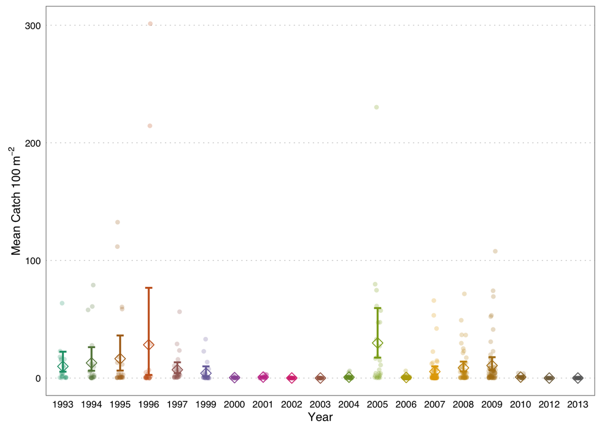

```r
bootPlot +
    scale_y_continuous(expression(Mean ~ Catch ~ 100 ~ m^{-2})) +
    geom_point(position = position_jitter(width = 0.3, height = 0),
               alpha = 0.25, shape = 16) +
    stat_summary(fun.data = ggBootCI,
                 fun.args = list(numSims = 1e3, ciMethod = 'bca'),
                 geom = "errorbar", width = 0.25, size = 0.75) +
    stat_summary(fun.y = "mean", geom = "point", size = 3, shape = 23)
```

### 3.0.3 Plot on log<sub>10</sub> scale

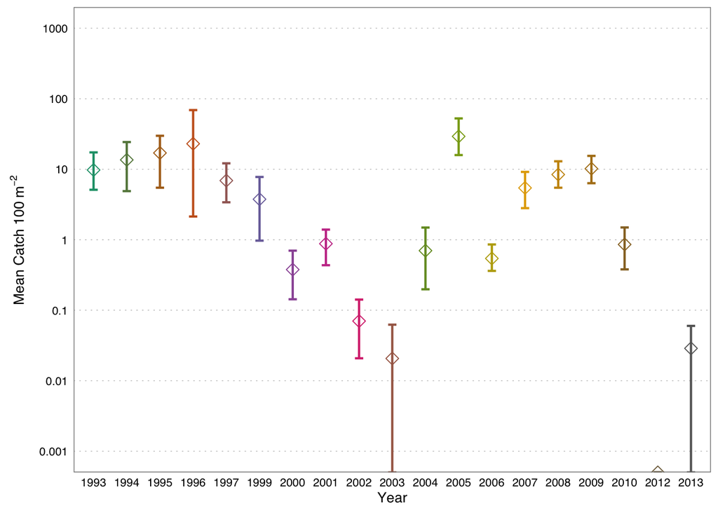

[output not shown]

[output not shown]

[output not shown]

```r
bootPlot +
    scale_y_continuous(expression(Mean ~ Catch ~ 100 ~ m^{-2}), trans = 'log10',
                       breaks = c(0.001, 0.01, 0.1, 1, 10, 100, 1000),
                       limits = c(0.001, 1000),
                       labels = function(n){format(n, scientific = FALSE,
                                                   drop0trailing = TRUE)}) +
    geom_errorbar(data = CPUEbootSumm, aes(ymin = low, y = mid, ymax = high,
                                           x = factor(Year), color = factor(Year)),
                  width = 0.25, size = 0.75) +
    geom_point(data = CPUEbootSumm, aes(y = mid),
               shape = 23, size = 3)
```